# Data-Driven Exploration of the R User Community Worldwide

Ben Ubah, Claudia Vitolo and Rick Pack

September 12, 2019

## Introduction

[R](https://r-project.org) is a programming language and environment for statistical computing and data visualization. An important component of the R ecosystem is its powerful user community that has continued to expand around the world over the years. [After announcing](https://www.r-consortium.org/blog/2019/08/12/r-community-explorer) an [R-Ladies](https://rladies.org) focused [open-source dynamic dashboard](https://benubah.github.io/r-community-explorer/rladies.html) that we built using R and Javascript, we have now extended that work to encompass all R user groups organized on [Meetup](https://meetup.com). R-Ladies is a world-wide organization to promote gender diversity in the R community. [R-Ladies](https://rladies.org) chapters are fully organized on Meetup. Most R user groups around the world are also organized on Meetup. Meetup provides an important API that aids in the retrieval of public information about groups organized on its platform.

In this article, we present our motivation for this work, the challenges we faced and how we surmounted them, the tools and procedures, as well as highlights on our final product.

## Why a dashboard to explore R user groups globally now?

1. Overview: We sought to present an objective representation of R’s popularity that would help members of the data science community accurately judge trends. By making our solution open-source and data-driven, we maximize transparency and enhance trustworthiness. This dashboard also helps leaders understand their user groups in a broader context while revealing opportunities for potential leaders to initiate new groups. Finally, the depiction of global distribution contributes to an important and evolving story about trends and opportunities in different parts of the world.

[figure not shown]

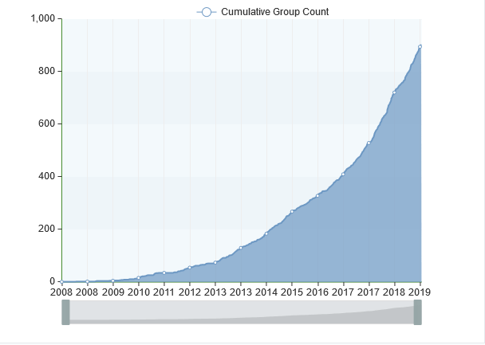

```
  Chart showing Cumulative Growth of R User Groups
```

2. Communities can flourish more easily when a unified, easily accessible and trusted resource presents information about its members and activity. Information regarding R user groups is spread across several sources and each source, while valuable, displays only a portion of available information. A list of some sources we found are:
- Meetup.com: https://www.meetup.com/topics/r-project-for-statistical-computing/
- Jumping Rivers: https://jumpingrivers.github.io/meetingsR/r-user-groups.html
- R-Ladies: https://gqueiroz.shinyapps.io/rshinylady/
- RConsortium: https://www.meetup.com/pro/r-user-groups/

3. For decision making, R centered organizations may need to geographically measure the presence of R users and groups for events planning, diversity programs, and other activities that could expand the use of the R language in under-represented regions.
4. New and existing R users would have a resource through which they can find groups near them and then learn how to get involved.
5. We want to help the thriving R community get even better.

## The R Consortium

Two out of three [top-level R Consortium projects](https://www.r-consortium.org/projects) are focused on R user groups. Appreciative of the R Consortium’s support of the R community, the dashboard map is optimized to point Inactive and Unbegun R user groups to [R Consortium’s RUGS grant program](https://www.r-consortium.org/projects/r-user-group-support-program).

## Classifying R User Groups

It was quite challenging to classify R user groups on Meetup for reasons including:

1. The names of some R user groups on Meetup comprise of “Location” + “R User Group” (e.g. “Las Vegas R User Group”), but in their topics or areas of focus on Meetup.com, they do not mention R.
2. The names of some R user groups on Meetup comprise of “Location” + “Data Science/Analytics Group” in their meetup names (e.g. Charleston Data Science), but in their topics or areas of focus, they mention “R Project for Statistical Computing”.
3. There are other groups that have Python, Julia, KNIME, Hadoop, etc. in their Meetup names, but yet mention “R Project for Statistical Computing” in their areas of focus. Some groups combine R and other tools in their names and topics.
4. Apart from “R Project for Statistical Computing”, many groups identify with the R language by selecting one of the following topics or areas of focus such as “Programming in R”, “Data Science using R”, “R Programming Language”, and several others.
5. Other unexpected name stylings were discovered as exemplified by: useRs, PhillyR, BelgradeR, etc.

It was significantly easier to find R-Ladies groups on Meetup because R-Ladies maintains a consistent naming structure across all groups - “R-Ladies” + “Location” (e.g. R-Ladies Madison). Only one `find_groups()` call from the `meetupr` package was sufficient.

## Our Solution

[Curtis Kephart](https://community.rstudio.com/u/EconomiCurtis) generously provided us a key to solving this problem - a technique based on string matching that he uses to retrieve upcoming R events. We extended his approach to:

- Retrieving all data science groups on Meetup (7700 +) and using string matching to select groups that contain strings like “r user”, “r-user”,“r-lab”,“phillyr”,“rug”,“bioconductor”,“r-data”,“rug” in their Meetup URL names. We then performed a second round of string matching to search for strings like “programming-in-r”, “r-programming-”, “-using-r”, “r-language”, and “r-project-for-statistical” in the groups’ `topics` field.
- Retrieving all user groups that mention “r-project-for-statistical-computing” in their topics separately.
- Retrieving all R-Ladies groups separately. We tried to use string matching to retrieve R-Ladies groups from the data science groups above but some groups were left out.
- Combining all the resulting data frames and removing duplicates.

We thus classified R user groups as groups that mention R in their names or in their topics. Every other approach we tried left out some R user groups. If you have any further ideas, we would be glad to hear from you.

## What Was Achieved

For the R user groups dashboard, the following was achieved:

1. We used the `meetupr` package to extract R user groups from Meetup.com
2. Improved the existing `find_groups()` and `get_events()` functions in `meetupr` to meet our [requirements](https://github.com/rladies/meetupr/pull/48). and switched from Meetup API keys to OAuth 2.0 authentication system
3. Transformed the data retrieved from Meetup via `meetupr` from data frames to JSON, GeoJSON and CSV
4. Stored the data by committing the JSON/GeoJSON/CSV files to the GitHub repository of the project.
5. Developed a static HTML dashboard interface based on an open-source Bootstrap template
6. Rendered the stored data via the dashboard interface
7. Automated the process of extracting R user groups, data transformation and storage.
8. Deployed it via GitHub Pages

### Switching from Meetup API keys to OAuth 2.0 Authentication System

During our work, Meetup announced a removal of keys from their authentication system and a migration to the OAuth 2.0 system which normally operates in an interactive session via a web browser. We implemented this migration for our code which runs in a non-interactive session over Travis by encrypting a locally generated token that is automatically cached by `httr`.

This token was generated in an interactive session and cached to a file named `.httr-oauth` in the current working directory, we saved it as an `.rds` file, encrypted it using `openssl` and pushed it to our repo. During each Travis build or Cron Job, Travis decrypts the token and it is loaded into the R scripts that make Meetup API calls. The ideas for this approach were borrowed from this [vignette on googlesheets](https://cran.r-project.org/web/packages/googlesheets/vignettes/managing-auth-tokens.html) and [Travis’ documentation](https://docs.travis-ci.com/user/encrypting-files/#using-openssl)

The `sodium` package as seen in this [article](https://gargle.r-lib.org/articles/articles/managing-tokens-securely.html) provides valuable encryption/decryption functionality as it could be adopted on all operating systems, on Travis, AppVeyor, and r-hub. We hope to explore this in the future for this project.

## Some Highlights from the Dashboard

1. A leaflet map with markers and pop-ups filled with information about the user groups’ membership, events, and status (active, inactive, or unbegun).

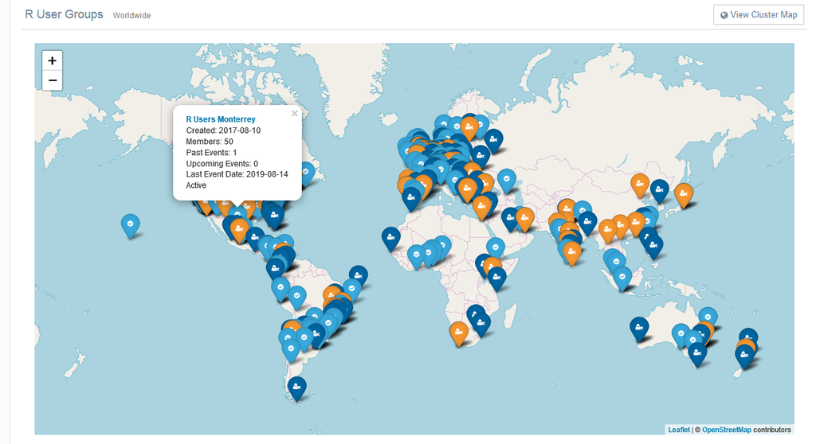

2. A [cluster map](https://benubah.github.io/r-community-explorer/rugs-cluster-map.html) to aggregate markers in clusters and provide cluster counts using `leaflet-markercluster.js` Javascript library.

[figure not shown]

3. Top destinations for R user groups based on membership across 6 regions.

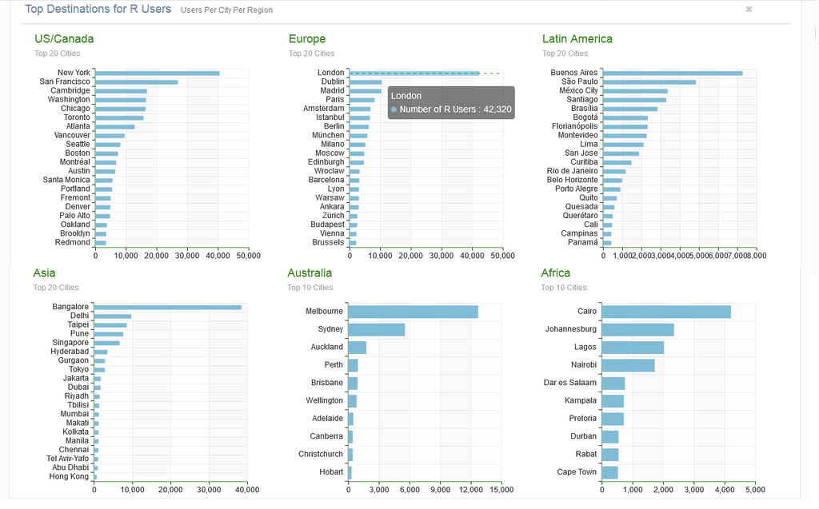

## The Tools

To accomplish the following, we used a mix of the tools listed below:

1. R, RStudio and the following packages:
   - meetupr, curl, jsonlite and leafletR
2. Javascript and the following libraries: jquery.js, d3.js, echarts.js, leaflet.js, leaflet-markercluster.js and lodash.js
3. Gentelella Admin Dashboard Bootstrap HTML template
4. Travis CI to build the project, execute R scripts and bash commands
5. Bash commands to call R scripts and commit modified files to GitHub

## How We Achieved It

R (for data-analysis) and JavaScript (for data-presentation) are the core tools employed to develop our solution considering the variety of options provided by this mix in terms of interactivity, automation and deployment. We applied the following procedure:

1. We used the `meetupr` R package to retrieve R User Groups from meetup.com.
2. We further analyzed this data by computing several summaries. We used the `leafletR` package to transform our data frame to GeoJSON. We used this GeoJSON file to create a leaflet map using `leaflet.js`. In this map, R user groups are separated into three groups with markers of three color categories: **Active** (blue), **Inactive** (dark-blue), and **Unbegun** (orange):
- **Active** groups have had an event in the past 180 days or have an upcoming event in the future
- **Inactive** groups have not had an event in the past 180 days and do not have an upcoming event
- **Unbegun** groups have not had an event in the past and none are planned for the future
3. Persisted all data and our summaries in CSV / JSON files. After each Travis build, the data and our summaries get updated directly from the Meetup API.
4. We wrote bash commands to run our R scripts, and commit updated CSV / JSON files to GitHub after every Travis build.
5. We setup Travis Cron Jobs to build this project daily and update our data. This update happens around 09:45AM UTC.
6. We then customized the Gentelella Admin Dashboard Bootstrap HTML template to our requirements.
7. Rendered our summaries via widgets on this dashboard. Used Javascript/libraries to produce maps, charts and tables.

## The Final Product

The final product is a [dashboard for R User Groups](https://benubah.github.io/r-community-explorer/rugs.html) that is updated daily via Travis, built using R and JavaScript and hosted via GitHub Pages.

At the time of writing, there are **907** R User Groups composed of **679,913 +** members, across **83** countries, **408** cities, with more than **16,600+** past events and **500+** upcoming events. **64%** of R user groups are active, **25%** are inactive, and **12%** are unbegun. Unbegun groups have members but have not started organizing events yet. Our observation is that members are added to the R community daily.

[figure not shown]

## Feedback

We are in hopes of expanding the features of this dashboard beyond its current state and we would love to hear from you if you have any ideas or find issues. We have received significant feedback from R users and these have helped us update our string matching process, helping us discover more user groups that mention R in their names and in their Meetup topics. Through these modifications, we have seen user-group count increase from 600+ to 900+ and several other figures have been automatically updated.

Feel free to Follow / Star the project at its GitHub repo: https://github.com/benubah/r-community-explorer/

## Acknowledgments

We appreciate [Curtis Kephart (RStudio)](https://community.rstudio.com/u/EconomiCurtis) for contributing code that helped us with ideas on classifying R user groups.

We also thank the authors of the `meetupr` package for their excellent work. Special thanks to [Jenny Bryan](https://github.com/jennybc), [Erin LeDell](https://github.com/ledell), and [Greg Sutcliffe](https://github.com/GregSutcliffe) for their help over the last month with implementing the requirements for the new Meetup OAuth 2.0 authentication system.

## Next

If you are interested in the data-driven exploration of a programming community, or the general data science community, we’d be glad to hear from you. Please [reach out at the issues section of this project](https://github.com/benubah/r-community-explorer/issues).